# Milestone Report

Martin J Page

20/11/2020

# Introduction

This report presents an exploratory data analysis of the Swiftkey dataset that aims to describes the major features of the training data and outline the plans for creating the predictive model.

# Data Preparation

## Load Librarues

```r
# install library if necessary
if(!require("tidyverse")) install.packages("tidyverse")
if(!require("stringr")) install.packages("stringr")
if(!require("stringi")) install.packages("stringi")
if(!require("cld2")) install.packages("cld2")
if(!require("RWeka")) install.packages("RWeka")
if(!require("tm")) install.packages("tm")

# load library
library(tidyverse)
library(stringr)
library(stringi)
library(cld2)
library(RWeka)
library(tm)
```

## Download and read data

```r
# Download ZIP Folder
url <- "https://d396qusza40orc.cloudfront.net/dsscapstone/dataset/Coursera-SwiftKey.zip"
if(!file.exists(".//Coursera-SwiftKey.zip")) download.file(url, destfile = ".//Coursera-SwiftKey.zip")

# Extract Files from ZIP
if(!file.exists(".//SwiftkeyData")) unzip(zipfile=".//Coursera-SwiftKey.zip", exdir= ".//SwiftkeyData")

# Read Data
enBlog <- readLines(".//SwiftkeyData//final//en_US//en_US.blogs.txt")
enTwitter <- readLines(".//SwiftkeyData//final//en_US//en_US.twitter.txt")
enNews <- readLines(".//SwiftkeyData//final//en_US//en_US.news.txt")
```

# Understanding the files

**Inspect the data**

```r
head(enBlog, 3)
```

```
[1] "In the years thereafter, most of the Oil fields and platforms were named after pagan â€œgodsâ€\u009d."
[2] "We love you Mr. Brown."
[3] "Chad has been awesome with the kids and holding down the fort while I work later than usual! The kids have been busy together playing Skylander on the XBox together, after Kyan cashed in his $$$ from his piggy bank. He wanted that game so bad and used his gift card from his birthday he has been…
```

```r
head(enTwitter, 3)
```

```
[1] "How are you? Btw thanks for the RT. You gonna be in DC anytime soon? Love to see you. Been way, way too long."
[2] "When you meet someone special... you'll know. Your heart will beat more rapidly and you'll smile for no reason."
[3] "they've decided its more fun if I don't."
```

```r
head(enNews, 3)
```

```
[1] "He wasn't home alone, apparently."
[2] "The St. Louis plant had to close. It would die of old age. Workers had been making cars there since the onset of mass automotive production in the 1920s."
[3] "WSU's plans quickly became a hot topic on local online sites. Though most people applauded plans for the new biomedical center, many deplored the potential loss of the building."
```

**Inspect the content of the files**

1. Size of the files

```r
blog_size <- file.info(".//SwiftkeyData//final//en_US//en_US.blogs.txt")$size / 1024^2
twitter_size <- file.info(".//SwiftkeyData//final//en_US//en_US.twitter.txt")$size / 1024^2
news_size <- file.info(".//SwiftkeyData//final//en_US//en_US.news.txt")$size / 1024^2
```

2. Number of lines in the files

```r
blog_lines <- length(enBlog)
twitter_lines <-length(enTwitter)
news_lines <-length(enNews)
```

3. Word counts of the files

```r
blog_words <-sum(stri_count_words(enBlog))
twitter_words <- sum(stri_count_words(enTwitter))
news_words <-sum(stri_count_words(enNews))
```

- Collect data into table

```r
fileSummary <- data.frame(Text = c("blog", "twitter", "news"), fileSize = c(blog_size, twitter_size, news_size), lineCount = c(blog_lines, twitter_lines, news_lines), wordCount = c(blog_words, twitter_words, news_words))
fileSummary
```

| Text | fileSize | lineCount | wordCount |
| --- | --- | --- | --- |
| blog | 200.4242 | 899288 | 38154238 |
| twitter | 159.3641 | 2360148 | 30218125 |
| news | 196.2775 | 77259 | 2693898 |

# Exploratory Analysis

1. Presence of profane terms

```r
#search for the profane word "fuck"
blog_fucks <- sum(str_detect(enBlog, "fuck"))
twitter_fucks <- sum(str_detect(enTwitter, "fuck"))
news_fucks <- sum(str_detect(enNews, "fuck"))

#search for the profane word "shit"
blog_shits <- sum(str_detect(enBlog, "shit"))
twitter_shits <- sum(str_detect(enTwitter, "shit"))
news_shits <- sum(str_detect(enNews, "shit"))

profaneSummary <- data.frame(Text = c("blog", "twitter", "news"), numberFucks = c(blog_shits, twitter_shits, news_shits), numberShits = c(blog_fucks, twitter_fucks, news_fucks))
profaneSummary
```

[output not shown]

2. Sentences containing URLs, Hashtags, and Mentions

```r
#search for the weblinks
blog_http <- sum(str_detect(enBlog, "http[s]?"))
twitter_http <- sum(str_detect(enTwitter, "http[s]?"))
news_http <- sum(str_detect(enNews, "http[s]?"))

#search for the hashtags or numbering (eg #1)
blog_hash <- sum(str_detect(enBlog, "#\\S+"))
twitter_hash <- sum(str_detect(enTwitter, "#\\S+"))
news_hash <- sum(str_detect(enNews, "#\\S+"))

#search for mentions/handles
blog_mention <- sum(str_detect(enBlog, "^@(?=.*\\w)[\\w]{1,15}"))
twitter_mention <- sum(str_detect(enTwitter, "^@(?=.*\\w)[\\w]{1,15}"))
news_mention <- sum(str_detect(enNews, "^@(?=.*\\w)[\\w]{1,15}"))

httpSummary <- data.frame(Text = c("blog", "twitter", "news"), httpCount = c(blog_http, twitter_http, news_http), hashtagCount = c(blog_hash, twitter_hash, news_hash), mentionCount = c(blog_mention, twitter_mention, news_mention))
httpSummary
```

| Text | httpCount | hashtagCount | mentionCount |
| --- | --- | --- | --- |
| blog | 1420 | 3961 | 93 |
| twitter | 336 | 212416 | 0 |
| news | 64 | 62 | 3 |

3. Foreign sentences and sentences containing non-standard English characters

```r
#search for non-English sentences
blog_foreign <- sum(detect_language(enBlog) != "en", na.rm = TRUE)
twitter_foreign <- sum(detect_language(enTwitter) != "en", na.rm = TRUE)
news_foreign <- sum(detect_language(enNews) != "en", na.rm = TRUE)

#search for non-Latin ASCII characters, including foreign letters and non UTF-8 characters
blog_notASCIIen <- sum(!stri_enc_isascii(enBlog))
twitter_notASCIIen <- sum(!stri_enc_isascii(enTwitter))
news_notASCIIen <- sum(!stri_enc_isascii(enNews))

foreignSummary <- data.frame(Text = c("blog", "twitter", "news"), foreignCount = c(blog_foreign, twitter_foreign, news_foreign), nonLetters = c(blog_notASCIIen, twitter_notASCIIen, news_notASCIIen))
foreignSummary
```

| Text | foreignCount | nonLetters |
| --- | --- | --- |
| blog | 4187 | 263027 |
| twitter | 3288 | 77431 |
| news | 284 | 10479 |

4. Unigrams

```r
#take a 10% sample of each of the text sources (uncleaned)
set.seed(1234)
text_sample <- c(sample(enBlog, length(enBlog)*0.1),
              sample(enTwitter, length(enTwitter)*0.1),
              sample(enNews, length(enNews)*0.1))

#compile into a corpus
text_corp <- VCorpus(VectorSource(text_sample))
```

```r
#define function to get the word frequencies from the corpus
getFreq <- function(tdm) {
  freq <- sort(rowSums(as.matrix(tdm)), decreasing = TRUE)
  return(data.frame(word = names(freq), freq = freq))
}

#define function to plot the top 30 word frequencies from the corpus
makePlot <- function(data, label) {
  ggplot(data[1:30,], aes(reorder(word, freq), freq)) +
         labs(x = "Terms", y = "Frequency", title = label) +
         theme(axis.text.x = element_text(angle = 60, size = 12, hjust = 1)) +
         geom_bar(stat = "identity", fill = "grey50") +
         coord_flip()
}
```

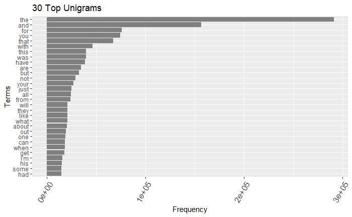

```r
# create document term matrix of unigrams (convert to lower case)
unigram_dtm <- TermDocumentMatrix(text_corp, control=list(tolower=TRUE))
uni_freq <- getFreq(removeSparseTerms(unigram_dtm, sparse = 0.999))
makePlot(uni_freq, "30 Top Unigrams")
```

```r
ftdm
```

[output not shown]

5. Bigrams

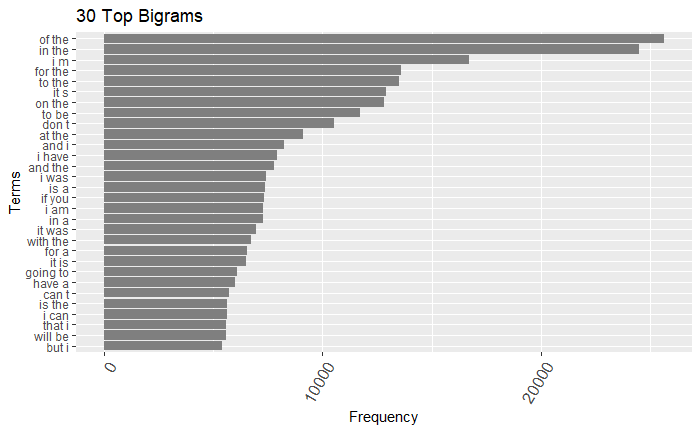

```r
# create document term matrix of bigrams (convert to lower case)
bi_tokeniser <- function(x) NGramTokenizer(x, Weka_control(min=2, max=2))
bigram_tdm <- TermDocumentMatrix(text_corp, control = list(tokenize = bi_tokeniser, tolower=TRUE))
bi_freq <- getFreq(removeSparseTerms(bigram_tdm, sparse = 0.999))
makePlot(bi_freq, "30 Top Bigrams")
```

6. Trigrams

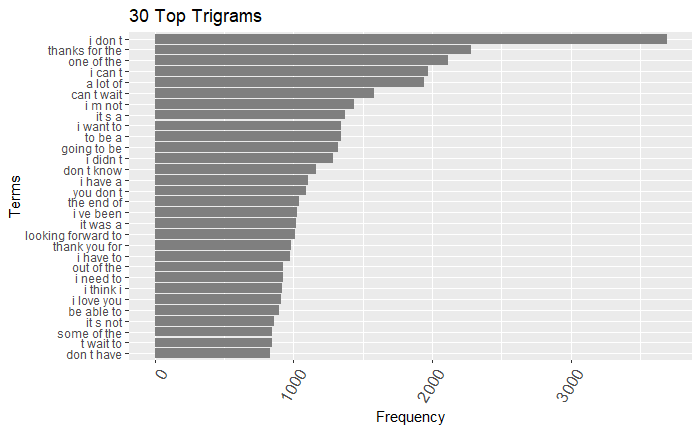

```r
# create document term matrix of trigrams (convert to lower case)
tri_tokeniser <- function(x) NGramTokenizer(x, Weka_control(min=3, max=3))
trigram_tdm <- TermDocumentMatrix(text_corp, control = list(tokenize = tri_tokeniser, tolower=TRUE))
tri_freq <- getFreq(removeSparseTerms(trigram_tdm, sparse = 0.999))
makePlot(tri_freq, "30 Top Trigrams")
```

# Conclusions

1. The data should be cleaned to contain just lower case letters with other punctuation and whitespaces stripped. In addition, #hashtags and @mentions should be removed. Symbols not encoded as UTF-8 should be converted to UTF-8 encoding and non-English characters should be removed.
2. The data contains profane terms (especially in the Twitter dataset) as well as web links (especially in the blogs dataset) that should be removed before modelling.
3. Some of the most frequent words are stop words. These should be kept as they are important for grammatically correct sentence and thus for prediction of the next word in a sentence. Some of the bigrams are slip contractions (like it’s -> it s). Contractions should be replaced by full terms.
4. My plan for building the model is to use the n-grams in the Katz Back-off Model or Simple Good-Turing model as well as the backoff model in the ANLP package in R.